# Practica 3: Regresión múltiple, control estadístico y parcialización

## 3.5 Coeficientes de Regresión parcial.

Los **coeficientes de regresión parcial** $b_{1}$ y $b_{2}$ son conocidos también como o pendientes de regresión parcial. Estos coeficientes cuantifican la relación entre Y, y cada variable independiente en términos constantes.

A continuación demostraremos qué significa mantener una variable constante matemáticamente a partir del proceso de parcializar una variable en otra.

Si X1 y X2 no estan corelacionadas, ninguna parcialización es requerido para estimar b1 y b2. Comunmente los regresores en el modelo están correlacionados en algún grado, sin embargo algunos regresores pueden estar más correlacionados que otros en modelos con varias regresores. Dos coeficientes de regresión para X1 y X2 pueden seguir estimandose al regresar Y en X1 y en X2 separadamente pero solo si X1 y X2 han sido parcializadas en sus relaciones mutuas. Esto implica construir una nueva medición de X1 y X2 que son independientes de otro.

Para hacer esto consideramos un modelo en el cual X2 es predicho por X1, o en este ejemplo, la ingesta de comida es predicha por el ejercicio.

En primer lugar se presenta el gráfico donde se muestra la relación entre comida y ejercicio.

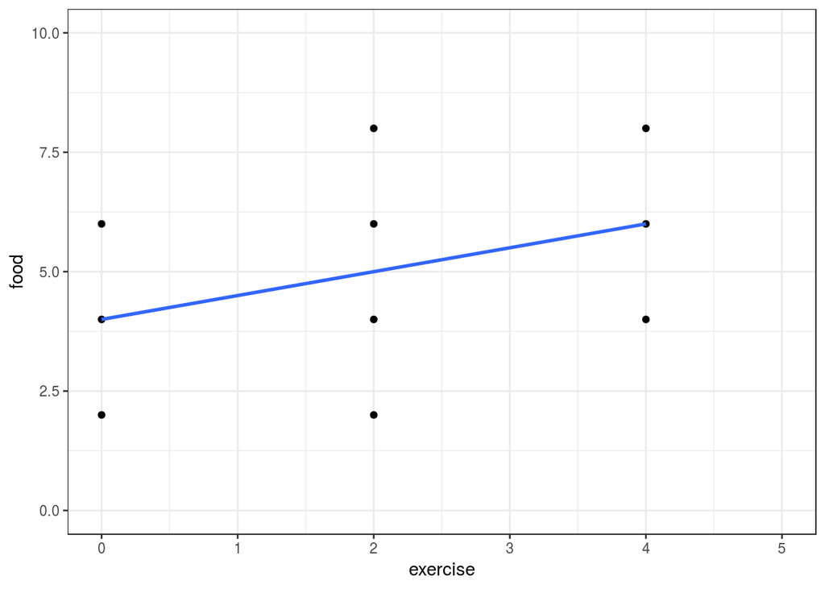

```r
ggplot(data, aes(x=exercise, y=food)) +
  geom_point() +
  geom_smooth(method = "lm", se=F)+
  xlim(0, 5)+
  ylim(0, 10)+
  theme_bw()
```

A continuación se presenta la estimación del modelo de regresión lineal:

```r
summary(lm(food~exercise, data=data))$coefficient
```

```
##             Estimate Std. Error  t value    Pr(>|t|)
## (Intercept)      4.0  1.0954451 3.651484 0.006480453
## exercise         0.5  0.4330127 1.154701 0.281536920
```

Al realizar la estimación de un regresor sobre el otro tenemos la siguiente ecuación

$$\hat{X_{2}}=4+0.5X_{1}$$

Este modelo de X2 genera una estimación de X2 dada la información que provee X1 para cada caso. A partir del comando *fitted.values()* podemos obtener los valores estimados(predichos) de X2. Además con el comando *residuals()* obtenemos una variable con la información de los residuos de esta regresión.

```r
#Estimamos la regresion exercise~food
reg_x1_x2 <- lm(exercise~food, data=data)
data$x1_2 <- fitted.values(reg_x1_x2) #variable de exercise estimada
data$resx1_2<- residuals(reg_x1_x2) #residuos de exercise estimada


#Estimamos la regresion food~exercise
reg_x2_x1 <- lm(food~exercise, data=data)
data$x2_1 <- fitted.values(reg_x2_x1) #variable de food estimada
data$resx2_1<- residuals(reg_x2_x1) #residuos de food estimada
head(data)
```

```
## # A tibble: 6 x 9
##      id exercise  food wtloss exercise1  x1_2 resx1_2  x2_1   resx2_1
##   <int>    <int> <int>  <int> <fct>     <dbl>   <dbl> <dbl>     <dbl>
## 1     1        0     2      6 0          1.14  -1.14   4.00 -2.00e+ 0
## 2     2        0     4      2 0          1.71  -1.71   4     5.55e-17
## 3     3        0     6      4 0          2.29  -2.29   4     2.00e+ 0
## 4     4        2     2      8 2          1.14   0.857  5    -3.00e+ 0
## 5     5        2     4      9 2          1.71   0.286  5    -1.00e+ 0
## 6     6        2     6      8 2          2.29  -0.286  5     1.00e+ 0
```

Los residuos del modelo de regresión lineal no estan correlacionados con todos los regresores del modelo. A continuación lo podemos ver, donde la correlación entre ejercicio no esta correlacionada con el residuo de la estimación de comida predicha por ejercicio.

```r
cor(data$exercise,data$resx2_1)
```

```
## [1] 3.022382e-17
```

De esta manera se puede entender que este residuo es el componente de la comida que es independiente del ejercicio. Es decir el residuo de esta regresión cuantifica lo unico de la variable comida, que no puede ser explicado por la variable ejercicio.

Ahora consideramos un modelo de regresión lineal en donde se estima la perdida de peso en base al residuo de la estimación de comida (en base a ejercicio). A continuación se presenta el grafíco de dispersión.

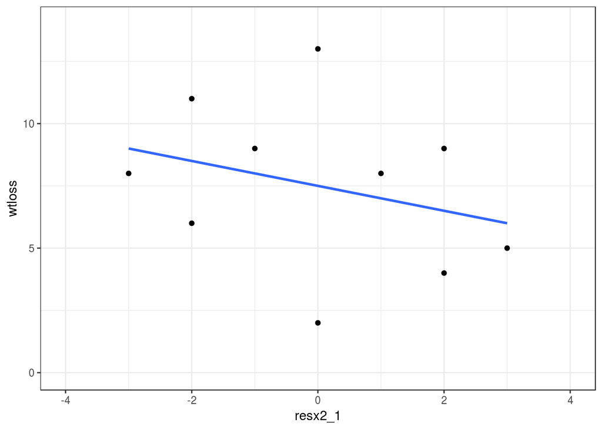

```r
ggplot(data, aes(x=resx2_1, y=wtloss)) +
  geom_point() +
  geom_smooth(method = "lm", se=F)+
  xlim(-4, 4)+
  ylim(0, 14)+
  theme_bw()
```

```r
summary(lm(wtloss~resx2_1, data=data))
```

```
##
## Call:
## lm(formula = wtloss ~ resx2_1, data = data)
##
## Residuals:
##    Min     1Q Median     3Q    Max
## -5.500 -2.125  0.000  2.125  5.500
##
## Coefficients:
##             Estimate Std. Error t value Pr(>|t|)
## (Intercept)   7.5000     1.0577   7.091 0.000103 ***
## resx2_1      -0.5000     0.5575  -0.897 0.395949
## ---
## Signif. codes:  0 '***' 0.001 '**' 0.01 '*' 0.05 '.' 0.1 ' ' 1
##
## Residual standard error: 3.345 on 8 degrees of freedom
## Multiple R-squared:  0.09137,    Adjusted R-squared:  -0.02221
## F-statistic: 0.8045 on 1 and 8 DF,  p-value: 0.3959
```

Como se puede apreciar la ecuación de mínimos cuadrados estimada para este modelo corresponde a:
$$\hat{Y}=7.5-0.5ResComida$$

```r
summary(m1)$coefficients
```

```
##               Estimate Std. Error   t value   Pr(>|t|)
## (Intercept) 7.14285714  2.9225839 2.4440213 0.04031087
## food        0.07142857  0.5408484 0.1320676 0.89819199
```

A partir de esto, se puede establecer que controlando por la frecuencia del ejercicio, o dando cuenta de las diferencias entre la frecuencias por ejercicio, o manteniendo constante el ejercicio, dos personas que difieren en 1 unidad de ingesta de comida, es estimado que se diferenciaran por 0.5 (gramos) en perdida de peso.